# HUK Coburg Code Challange

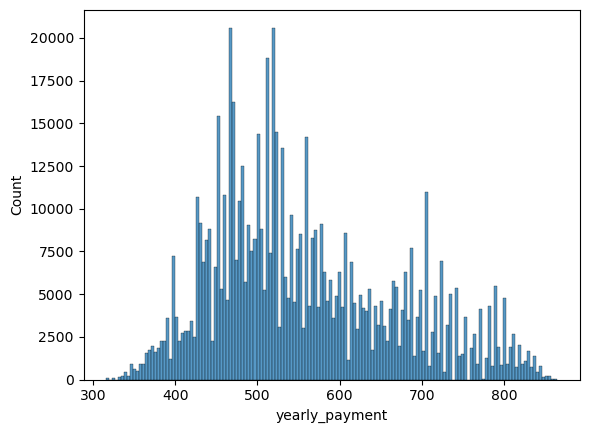

```python
sns.histplot(df_final,x="yearly_payment")
plt.show()
```

as shown in this graph, the distribution of yearly payments is well distributed between 300 and 900 a year. Compared to the first approach these results are favourable and avoid the shown pitfalls of customers paying nothing at all, or negative payment amounts

```python
print(df_final["yearly_payment"].sum())
print(df_sev["ClaimAmount"].sum())
```

```
378323408.80720556
59909212.0
```

As shown by the summations, the claim amount would be covered by this modell with significant headroom. Since BonusMalus is not applied at this time, the final amount to pay could be significantly lower for most customers. To be competitive to other insurances this amount could be scaled down for all customers.

To additionally make the classification modell more explainable we could also use decision tree and plot it as shown below.

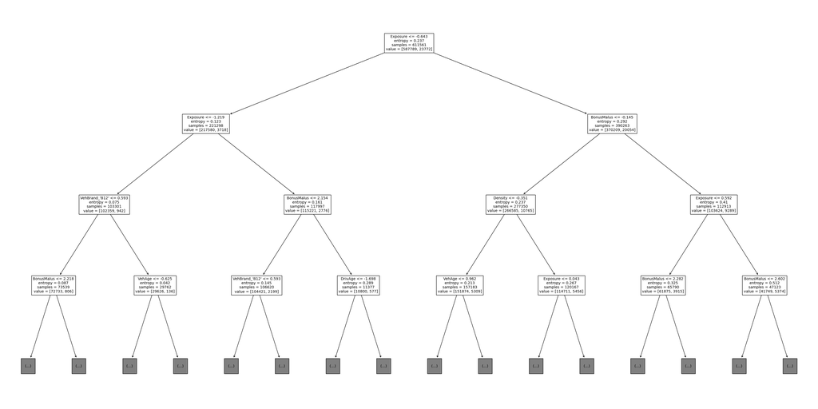

```python
from sklearn.tree import plot_tree
fig = plt.figure(figsize=(40,20))
plot_tree(dt_search.best_estimator_,feature_names=df_final.columns,max_depth=3)
plt.show()
```

The plotted levels show that the most influencal features used in the first few levels of the tree are Exposure, Bonus Malus, Density, Vehicle Brand, Vehicle Age, and Driver Age. Given the general knowledge about insurances this result seems reasonable.

While further improvements with broader hyperparameter optimization, usage of better suited ANNs, other algorithms like XGBoost, lightgbm etc. could yield better results, the general performance of the machine learning modell is still reasonably well. The distribution of yearly payments seems fair, since all customers pay for their insurance, but only few customers have to pay a significantly higher amount given their risk.